# ART and mQTLs

Can assisted reproductive technologies (ART) impact the association between DNA methylation and genotypes?

Julia Romanowska

2026-05-22

Photo by [Zoltan Tasi](https://unsplash.com/@zoltantasi?utm_content=creditCopyText&utm_medium=referral&utm_source=unsplash) on [Unsplash](https://unsplash.com/photos/time-lapse-photography-of-mountain-pass-84gTD1AJTWo?utm_content=creditCopyText&utm_medium=referral&utm_source=unsplash)

## OUTLINE

### Background

#### DNAm and mQTLs

#### DNAm reprogramming and ART

### methods

### some results

### discussion

## DNA methylation (DNAm)

[figure not shown]

- *CpG* - most popular methylation site
- non-uniformly distributed
- ‘marker’ for gene activation

## DNAm reprogramming

wave of demethylation followed by rapid re-methylation

- paternal DNA is *demethylated* faster than maternal
- at **blastocyst** stage (days 5–9), DNAm level is lowest (ca.20% of all CpGs)
- freezing of eggs could influence de-methylation and differentiation

[src: Albert and Greenberg, Development (2023); Greenberg, Front.Cell Develop.Biol. (2021)]

## DNAm reprogramming & ART

### ART = assisted reproductive technology

[figure not shown]

## DNAm reprogramming & ART

### ART = assisted reproductive technology

[figure not shown]

src: Guo, H., et al. (2014). *Nature*, *511*(7511), 606–610.

## mQTL

**methylation quantitative locus**

*SNP–CpG pair:*

association between  
*methylation* status of that CpG and  
*allele* at that SNP

- *cis*-mQTLs and *trans*-mQTLs

## mQTL

**methylation quantitative locus**

*SNP–CpG pair:*

association between  
*methylation* status of that CpG and  
*allele* at that SNP

- *cis*-mQTLs and *trans*-mQTLs

## Aim of the study

*do ART procedures influence re-methylation processes?*

(using mQTLs as tool)

**mQTL:** No

**ART-effect:** No

[figure not shown]

**mQTL:** No

**ART-effect:** No

[figure not shown]

**mQTL:** No

**ART-effect:** Yes

[figure not shown]

**mQTL:** Yes

**ART-effect:** No

[figure not shown]

**mQTL:** Yes

**ART-effect:** Yes (after fertilization?)

[figure not shown]

**mQTL:** Yes

**ART-effect:** Yes

**PoO ART-effect:** Yes (maternal line?)

[figure not shown]

**mQTL:** Yes

**ART-effect:** Yes

**PoO ART-effect:** Yes (paternal line?)

[figure not shown]

## methods

### data

- **genetic data** - MoBa
- **DNAm data** - START

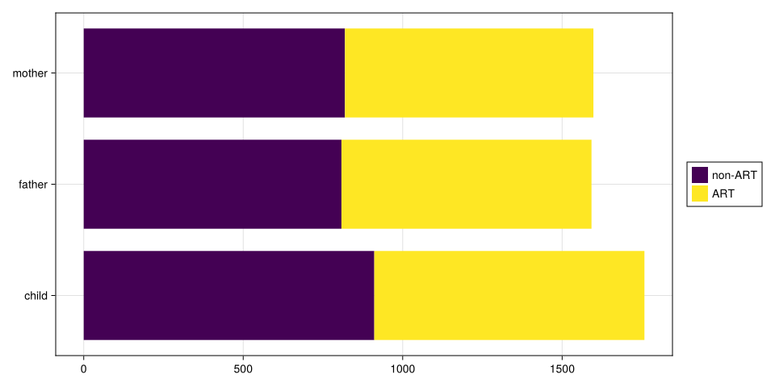

## methods

### tools

- `PLINK`
- `R`
- `JuliaLang`
- `snakemake`

## methods

1. prepare SNP-CpG list:
   1. SNP–CpG distance of max.100 kbp
   2. SNP–CpG distance of min. 50 bp
   3. min.10 persons with DD of minor allele
   4. DNAm range > 0.1
2. agnostic search for mQTLs *in parents*
3. select the significant mQTLs *(FDR < 0.1)*
4. remove outliers
5. check for association *in children*

## methods – models

5. check for association *in children*
- *quantile regression*[*]
- using three models:
  - DNAm $\sim$ SNP $+$ case_control_status
  - DNAm $\sim$ SNP $\times$ case_control_status
  - DNAm $\sim$ SNP, *stratified by case_control_status*

[*] comparing *medians* instead of means!

# Results

*mQTLs in parents*

## How many tests and *cis*-mQTL pairs?

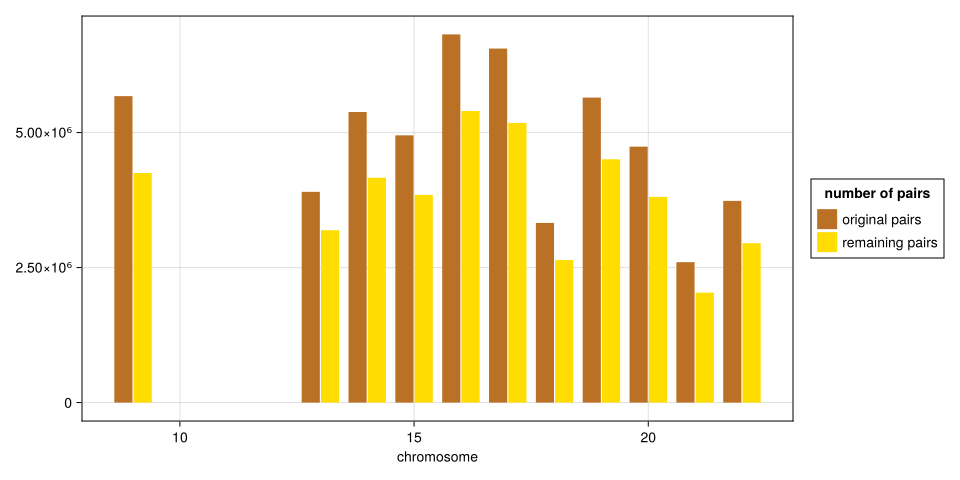

## Timing of runs

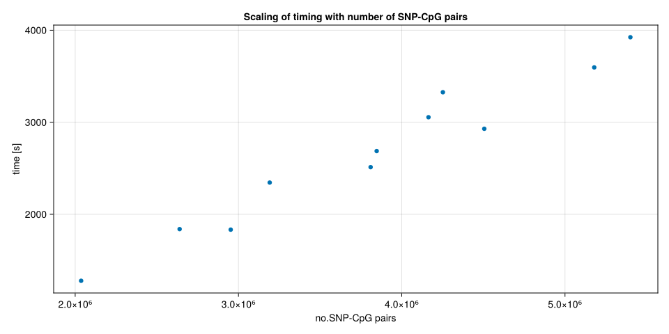

## How many *cis*-mQTL pairs?

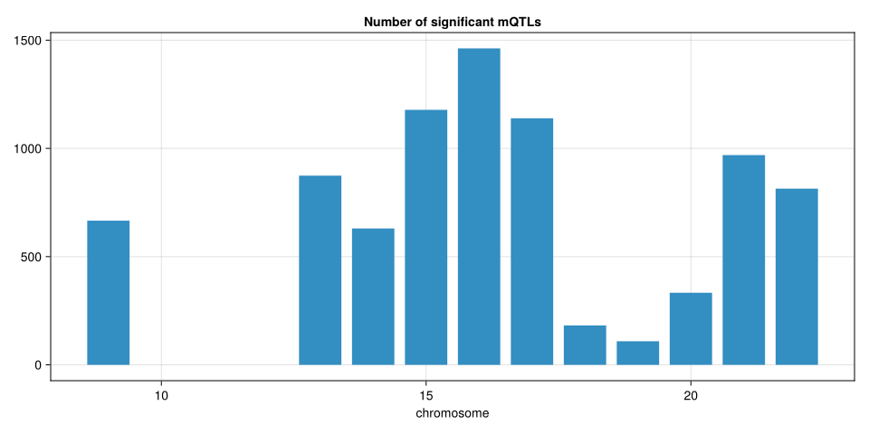

- significance: FDR $< 0.1$ per chromosome

# Results

*mQTLs in children*

## How many *cis*-mQTL pairs?

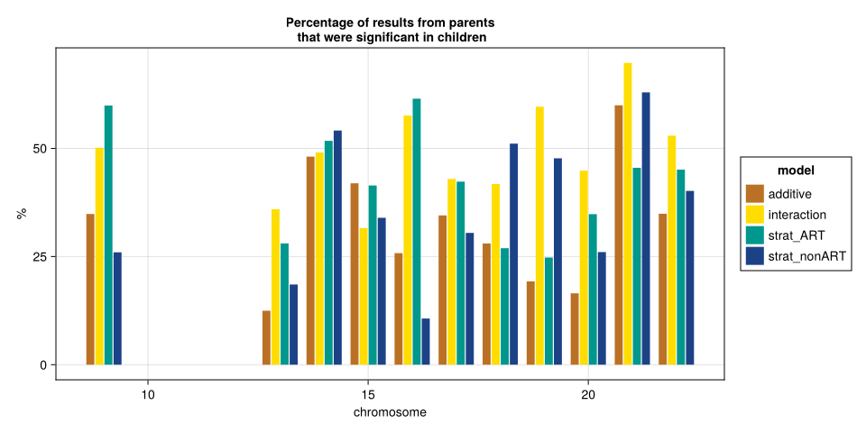

## model: *additive*

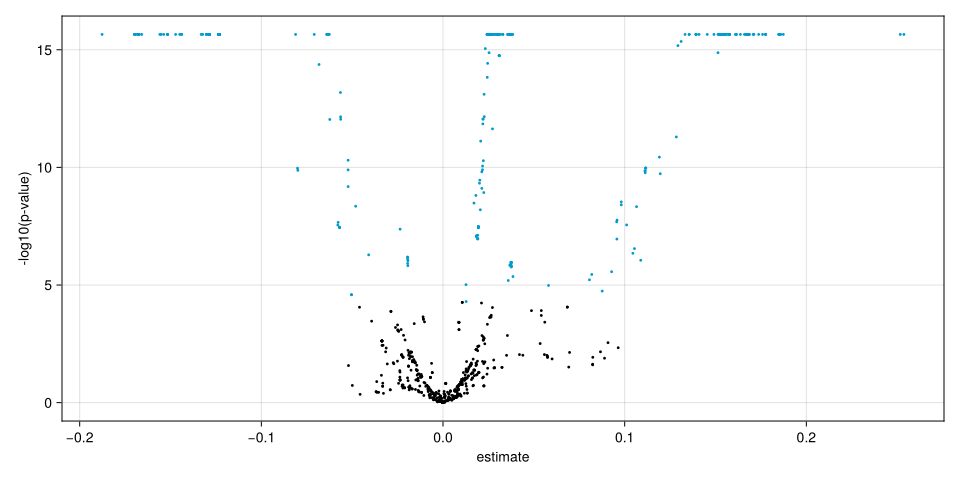

Volcano plot for additive model, using DNAm data from children.

## model: *interaction*

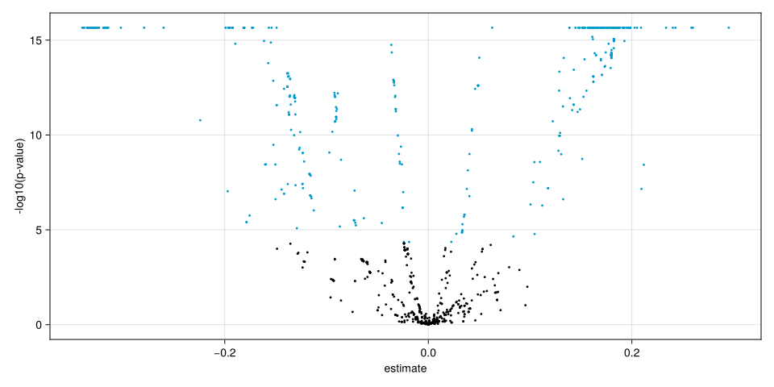

Volcano plot for interaction model, using DNAm data from children.

## model: *stratified*

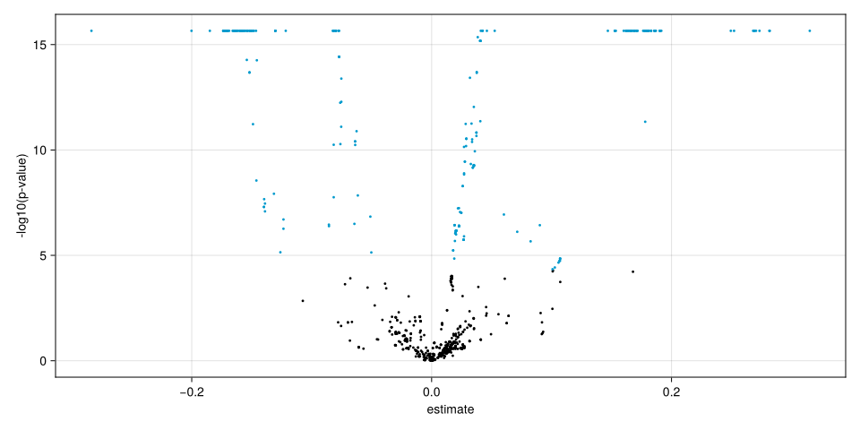

‘ART’ group

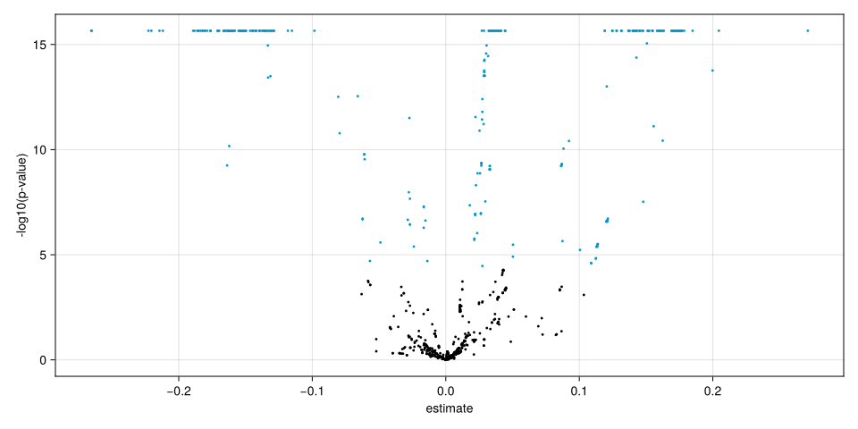

‘non-ART’ group

## Stratification model

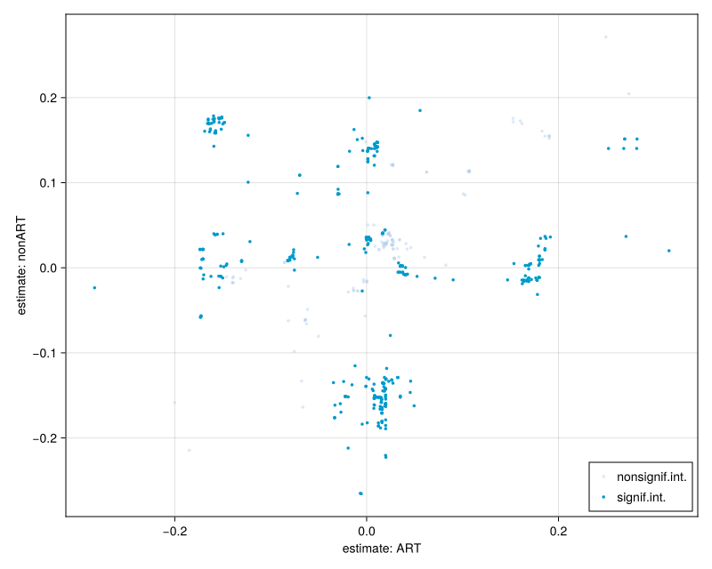

## Stratification model

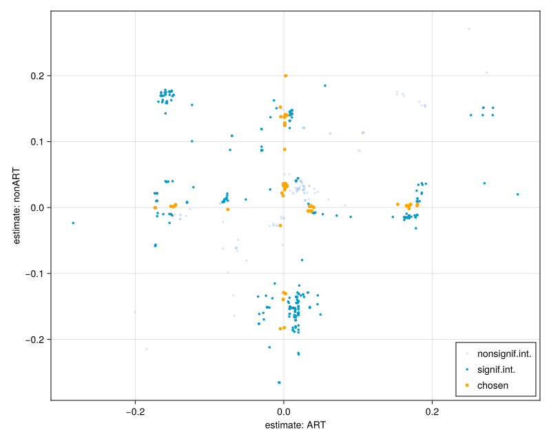

## “Interesting” findings

| CpG InlineStrings.String15 | nrow Int64 |
| --- | --- |
| cg17612569 | 41 |
| cg20741235 | 32 |
| cg21139150 | 17 |
| cg22706458 | 1 |

each SNP appear only in one mQTL

## Example – genomic location

[figure not shown]

## Example

[figure not shown]

## Example

[figure not shown]